# PackML HMI

# Siemens / Qimarox HMI Evaluation

### Siemens / Qimarox Upstream Machine Speed:

What is the reported speed of the upstream machine in packages per minute (ppm)?

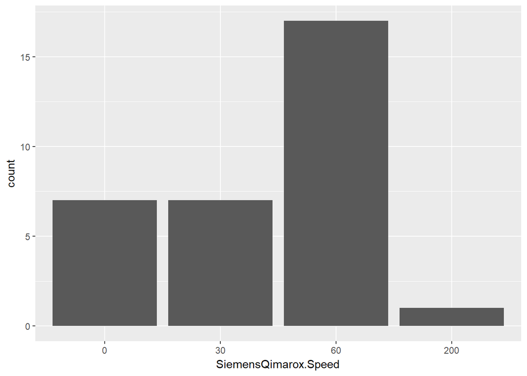

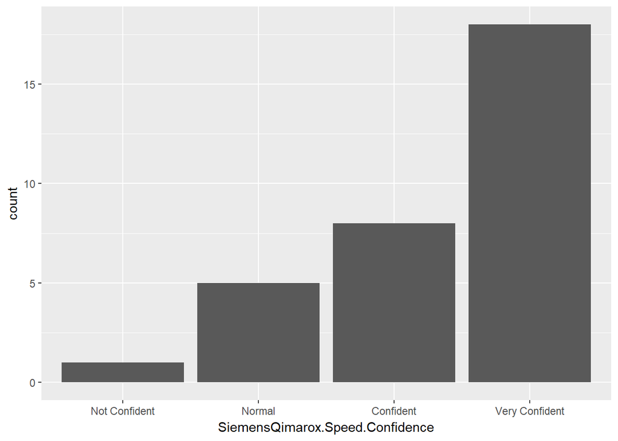

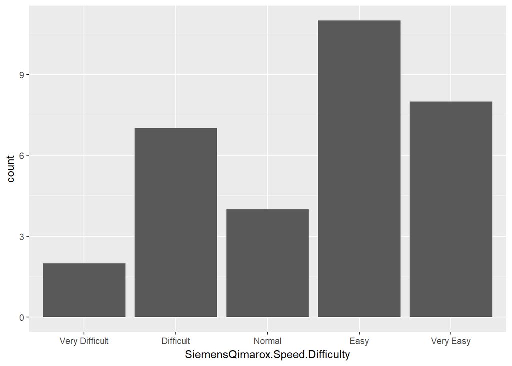

### Siemens / Qimarox PLC IP Address:

What is the reported PLC IP Address?

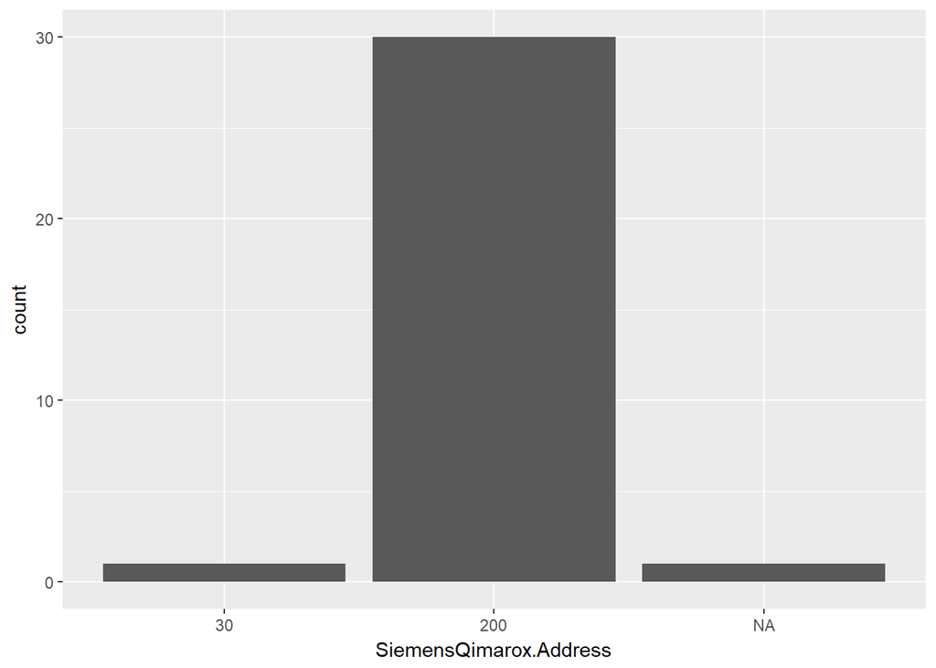

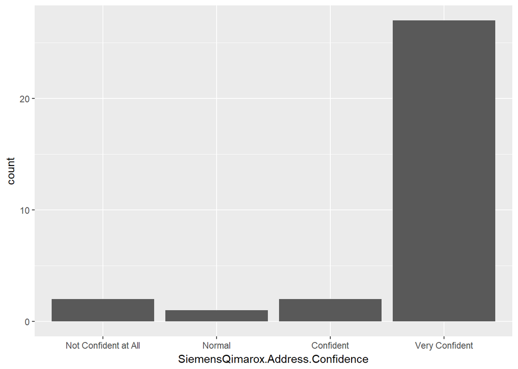

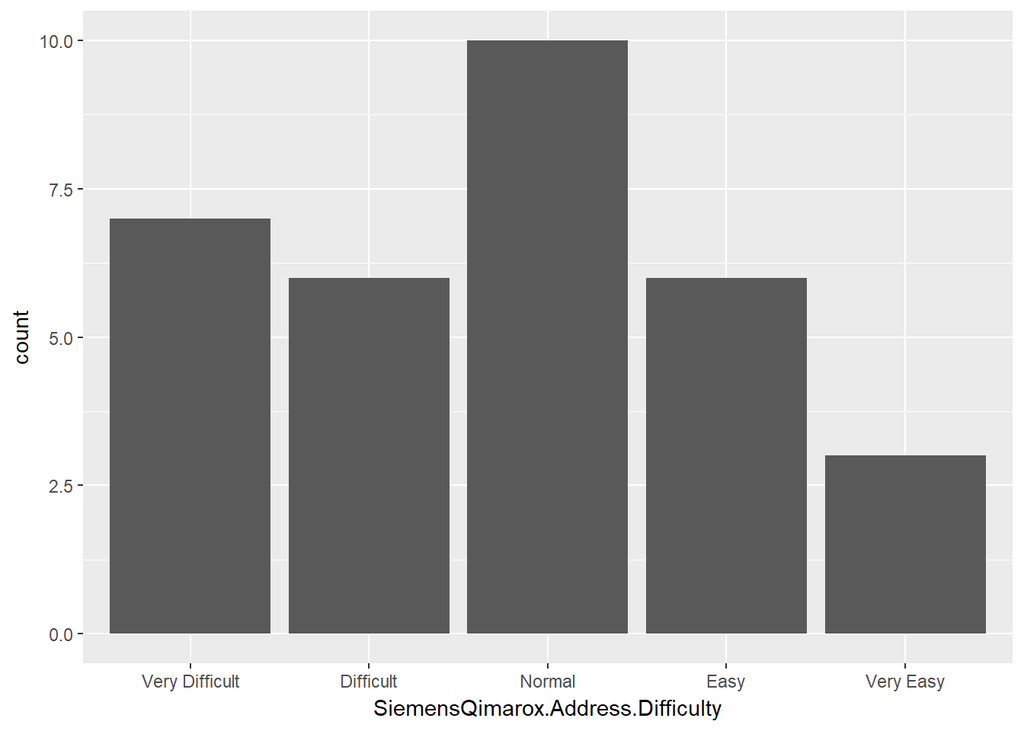

### Siemens / Qimarox Reject Count

What is the currently reported reject count?

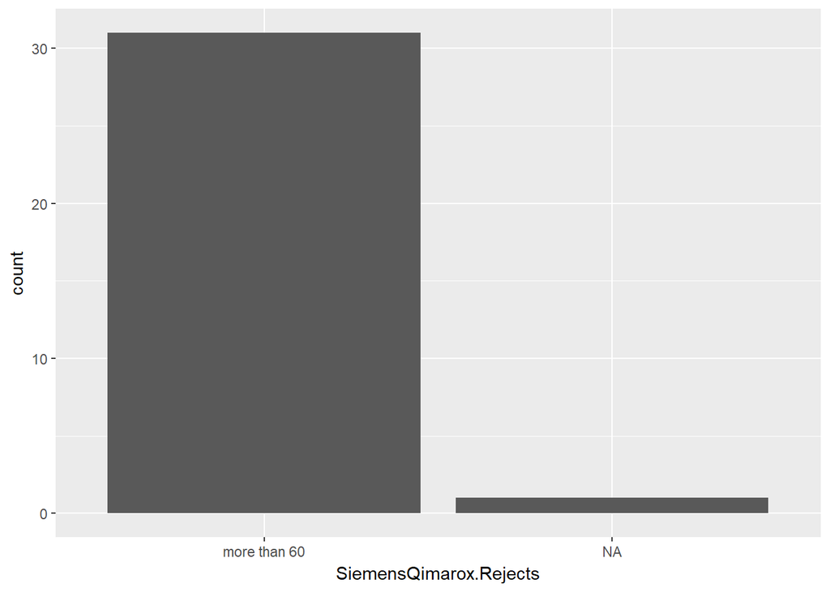

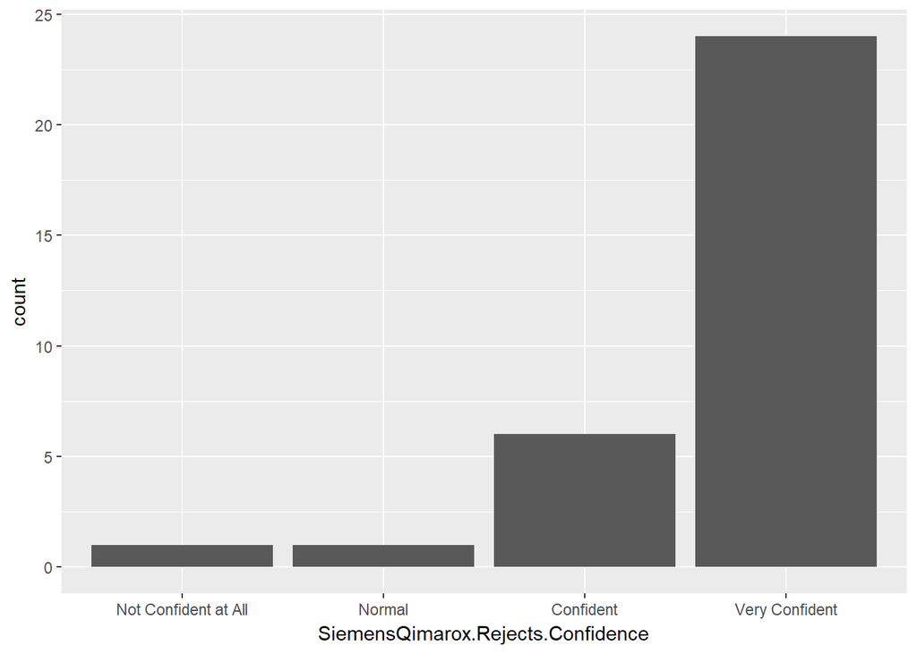

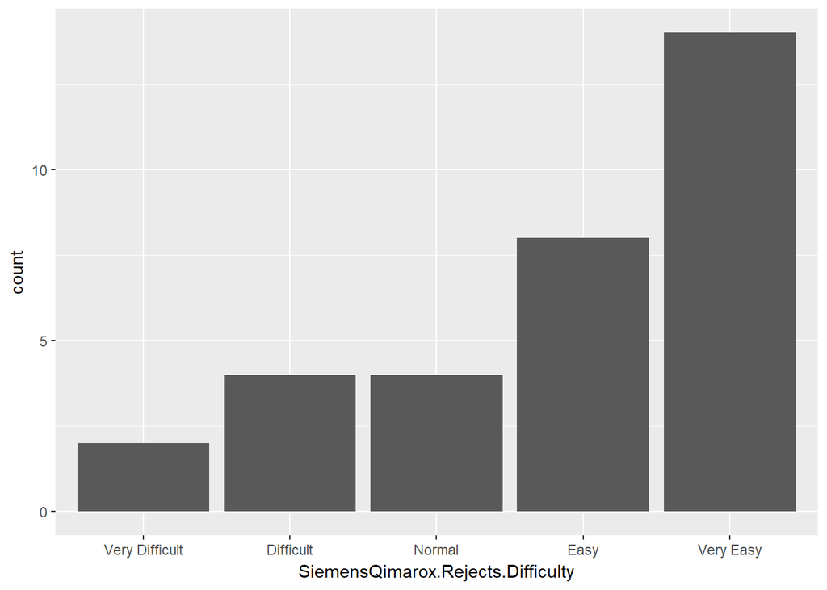

### Siemens / Qimarox Alarm:

Which of the following is the most recent alarm?

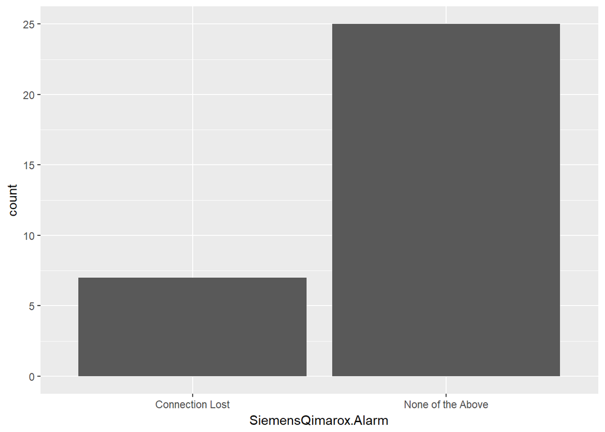

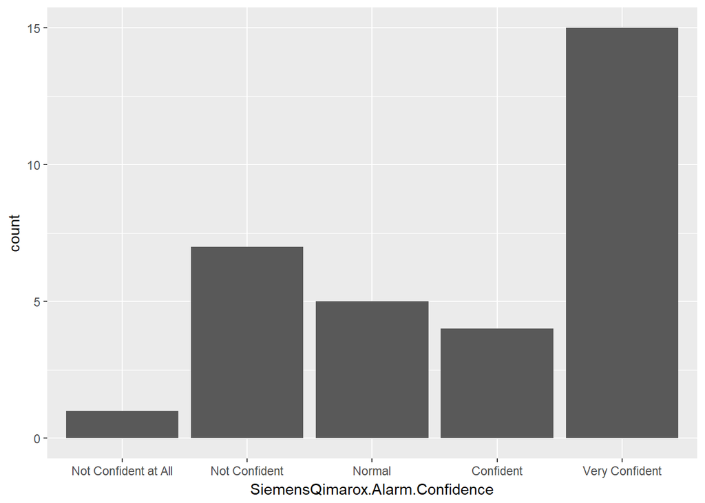

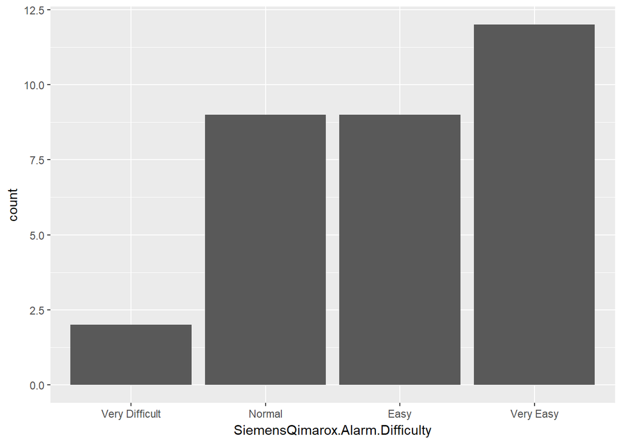

## Siemens / Qimarox Difficulty

Overall, how difficult was the Siemens/Qimarox interface for the above tasks?

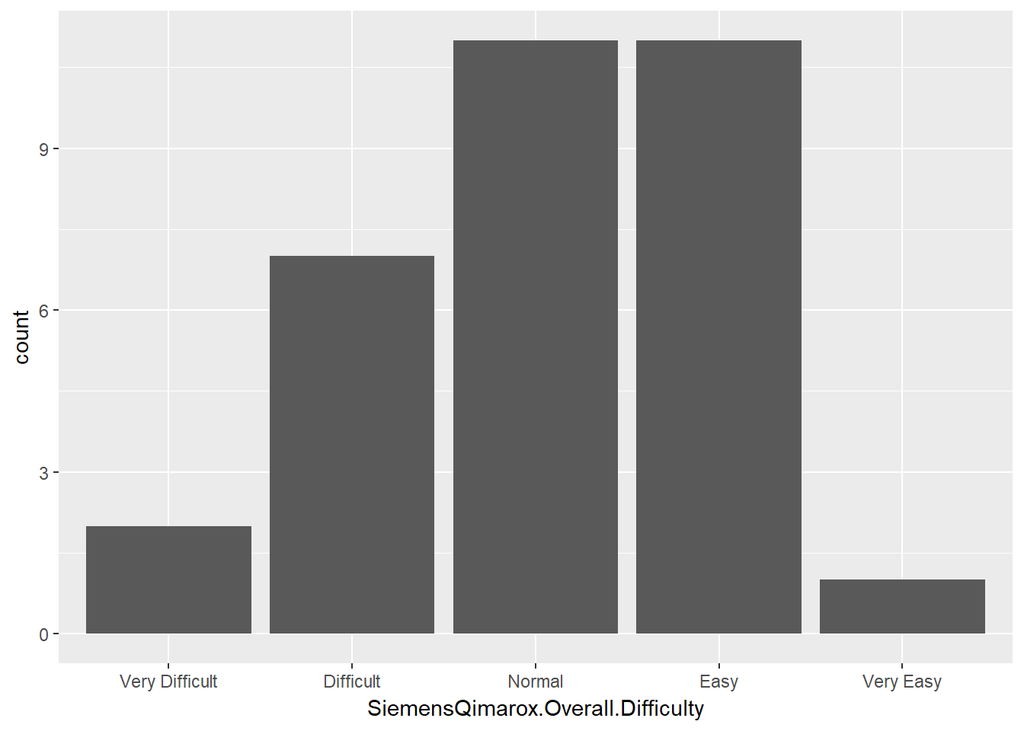

## Mixed Difficulty

Would it be difficult working on a production line with a mix of these interfaces?

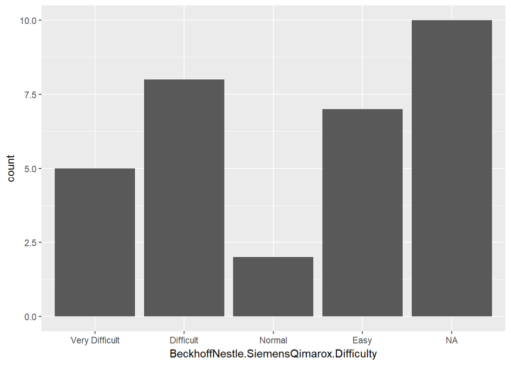

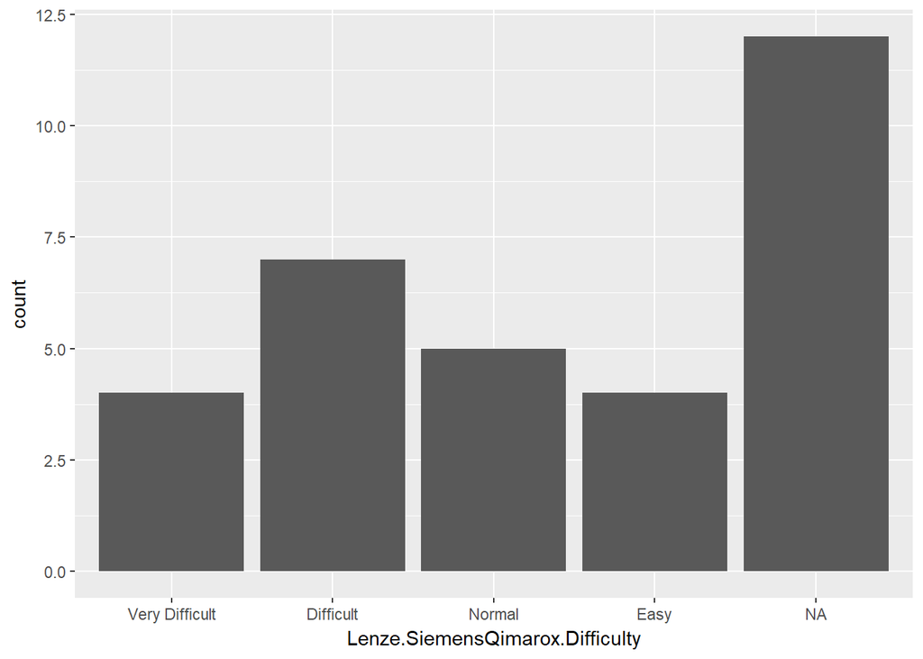

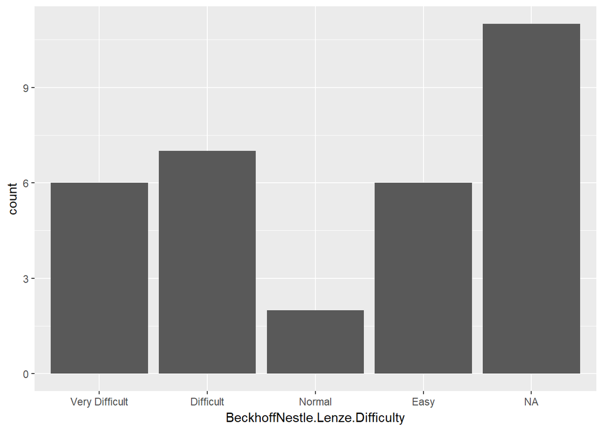

# HMI Evaluation Summary

### Overall Preference:

If you were assigned a position as a line operator, which interface would you prefer using?

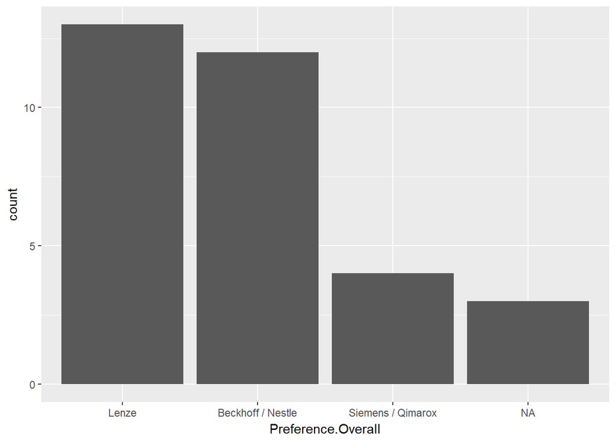

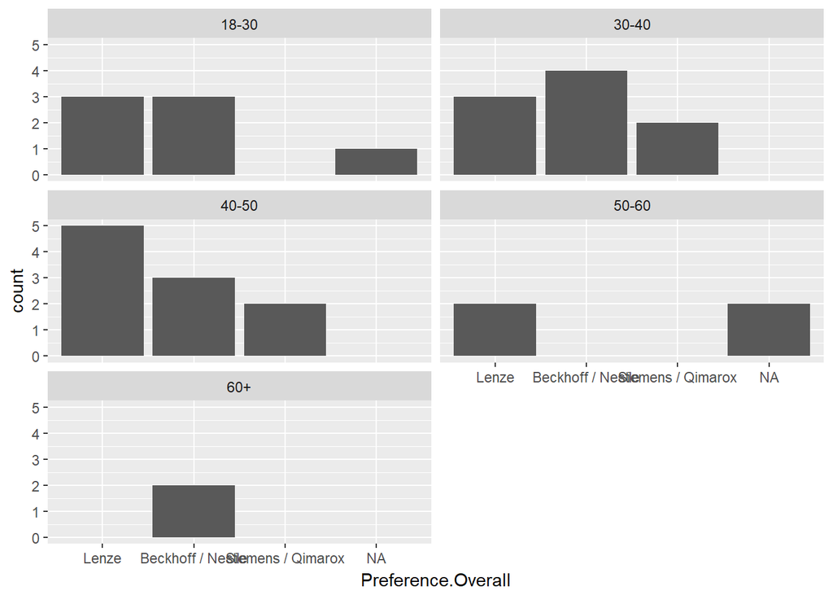

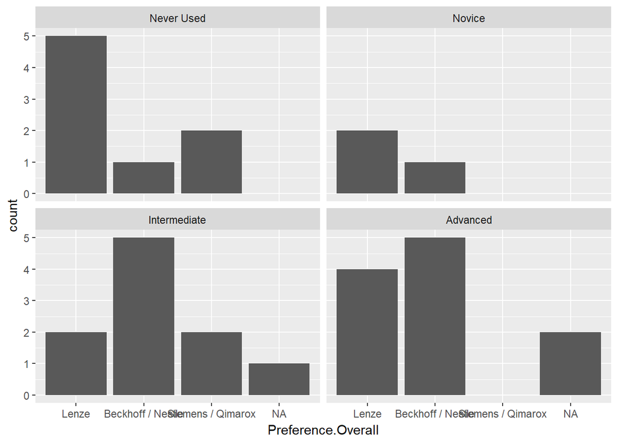

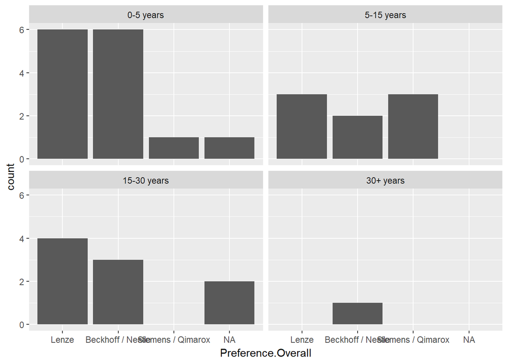

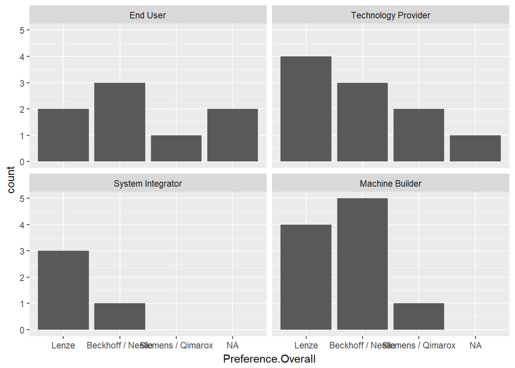

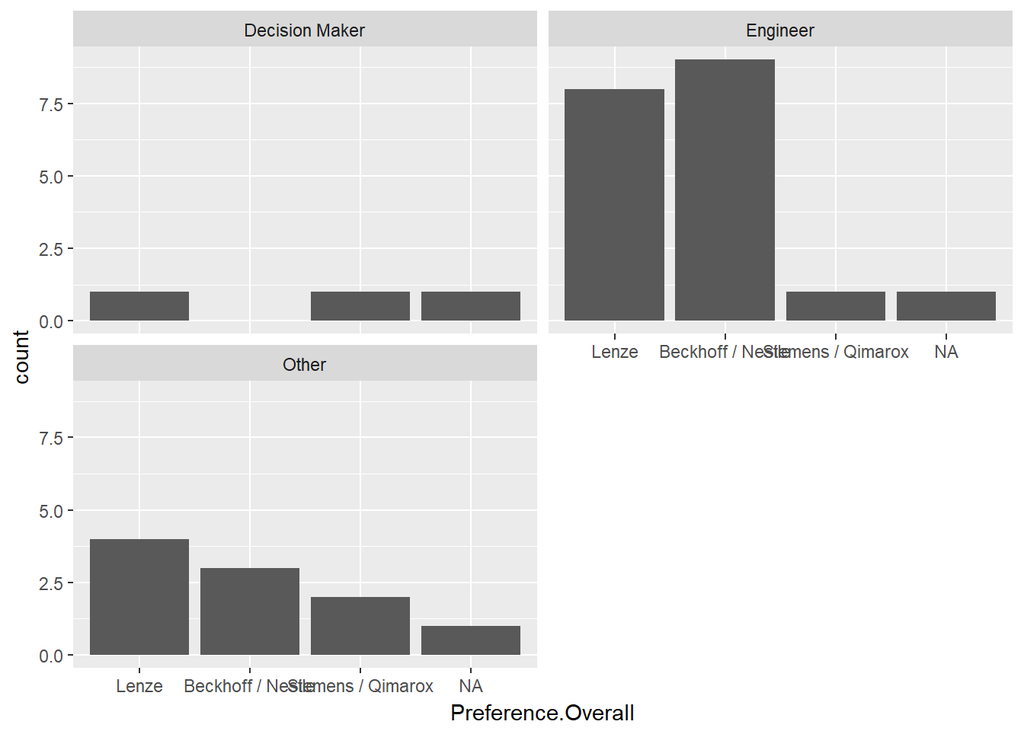

### Perceived Challenges:

Working with a mixture of these interfaces on a regular basis would lead to reduced efficiency.

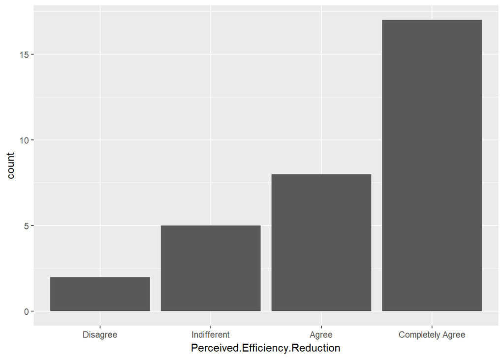

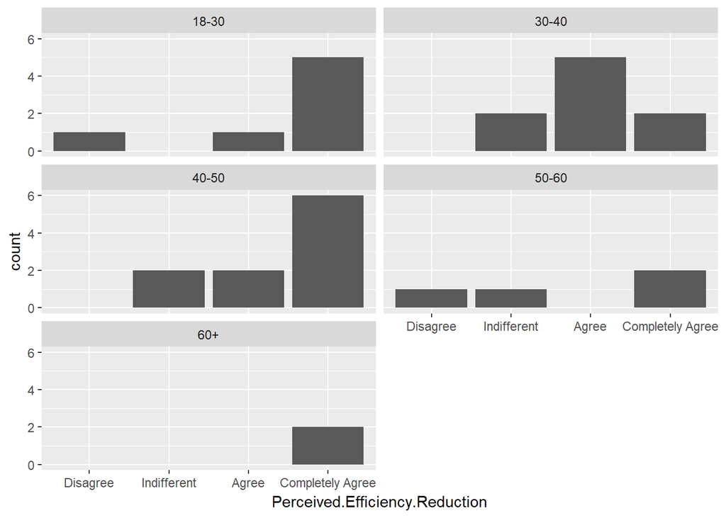

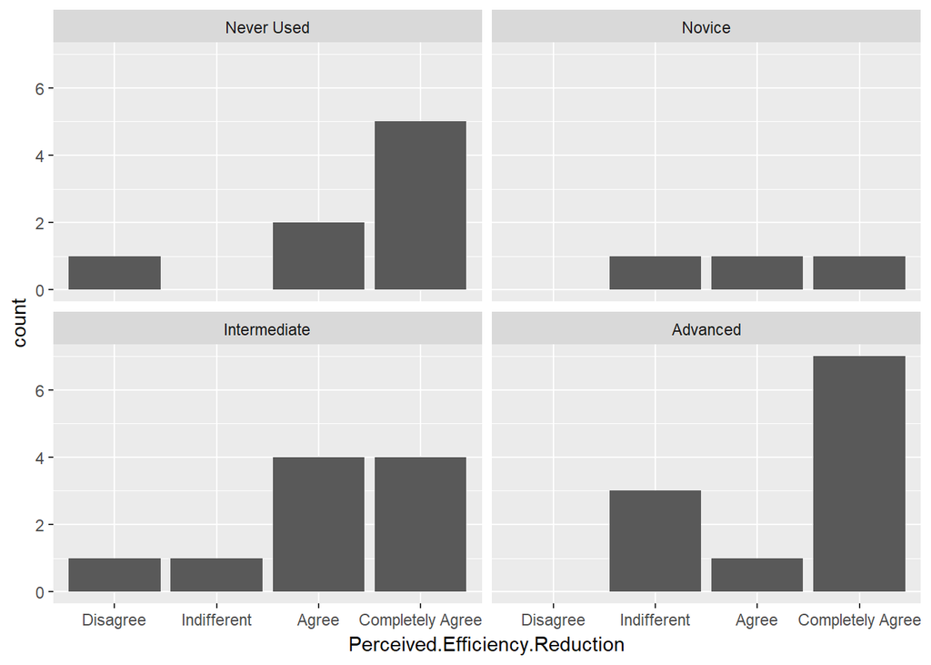

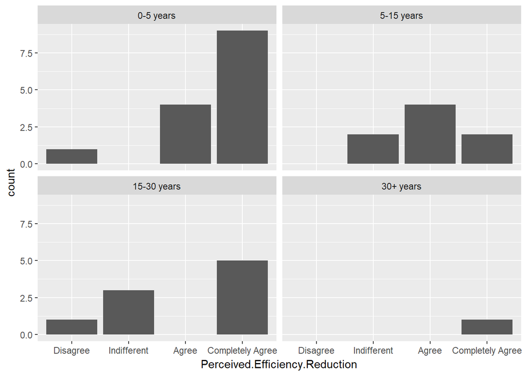

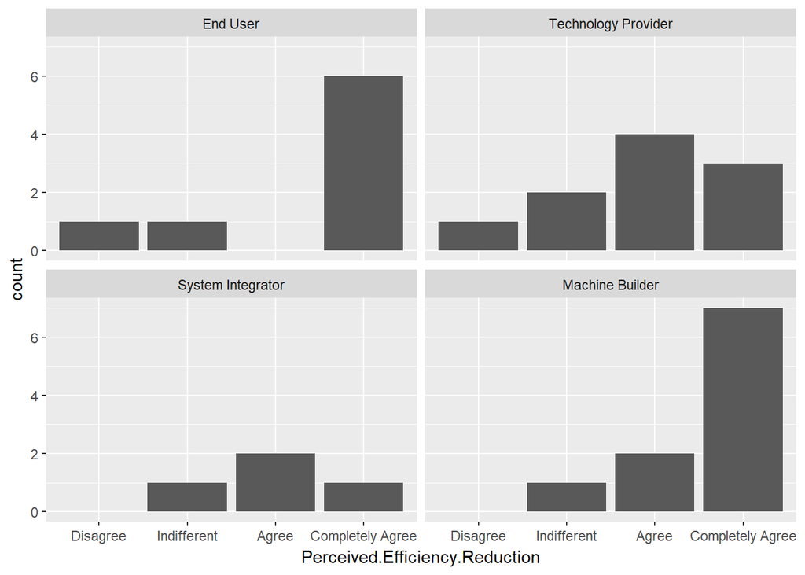

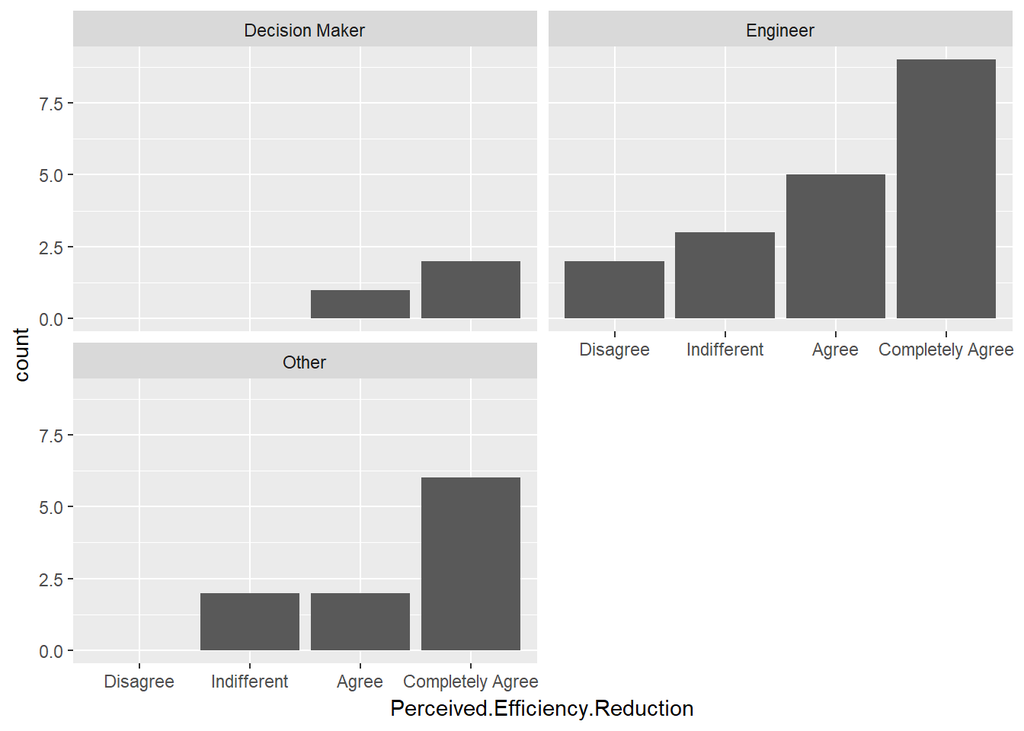

Working with a mixture of these interfaces on a regular basis would lead to safety issues.

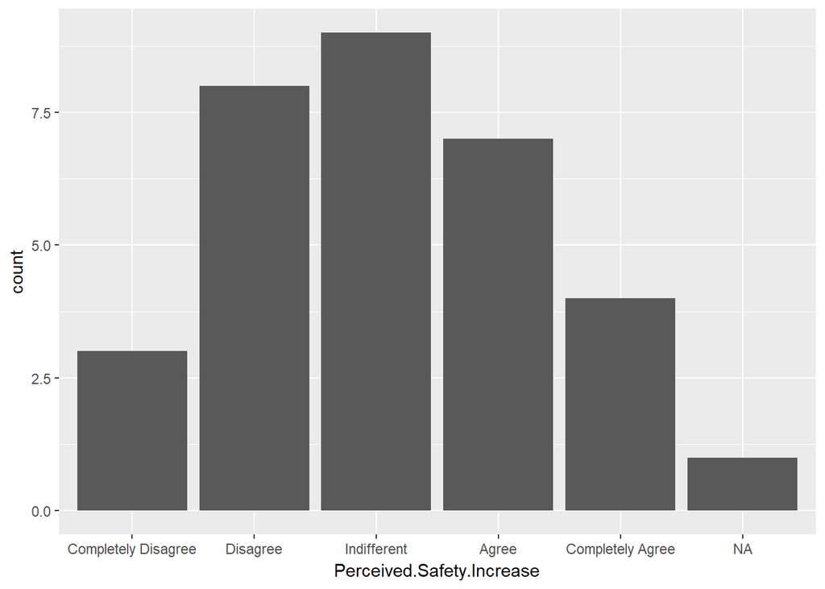

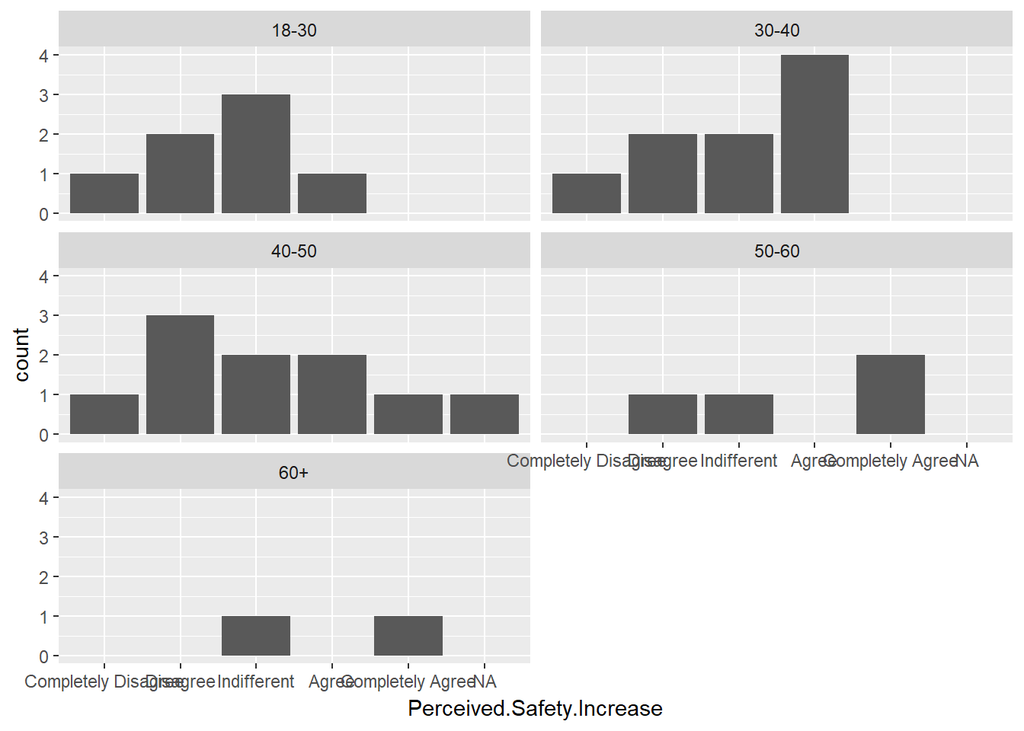

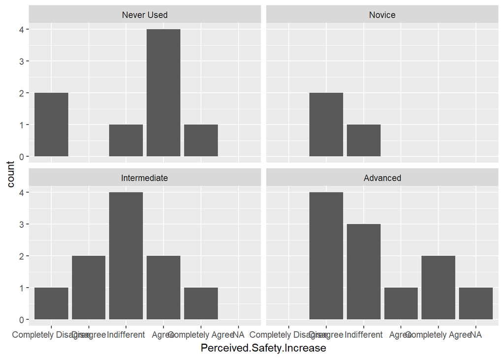

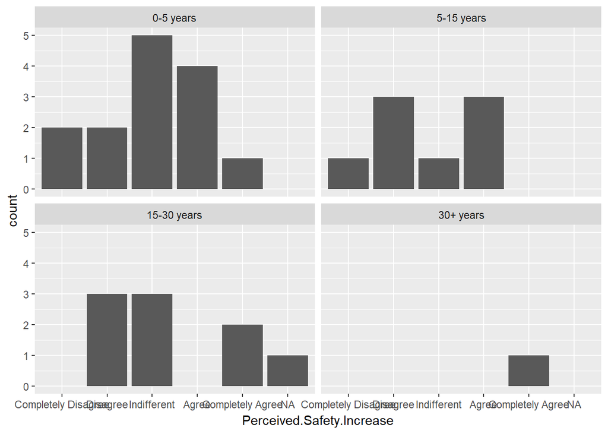

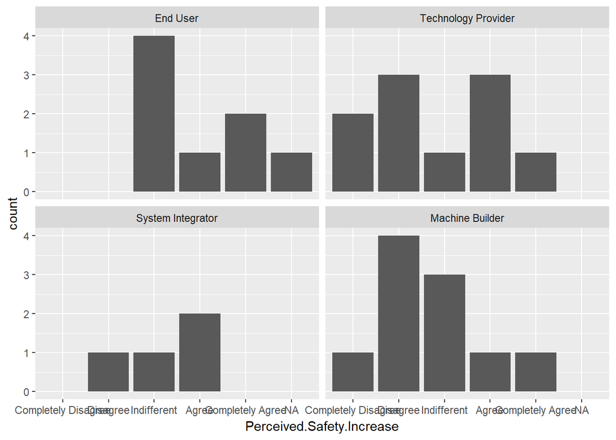

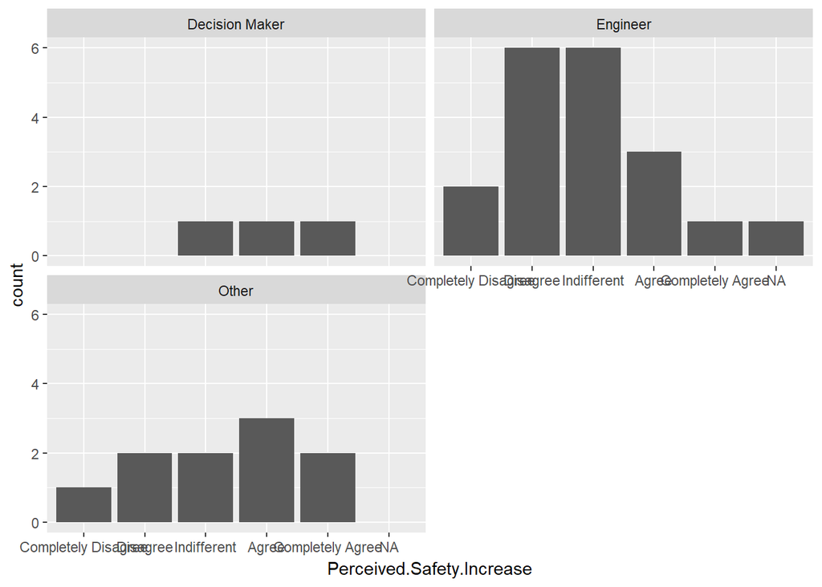

Standardizing on my preferred interface would significantly reduce downtime.

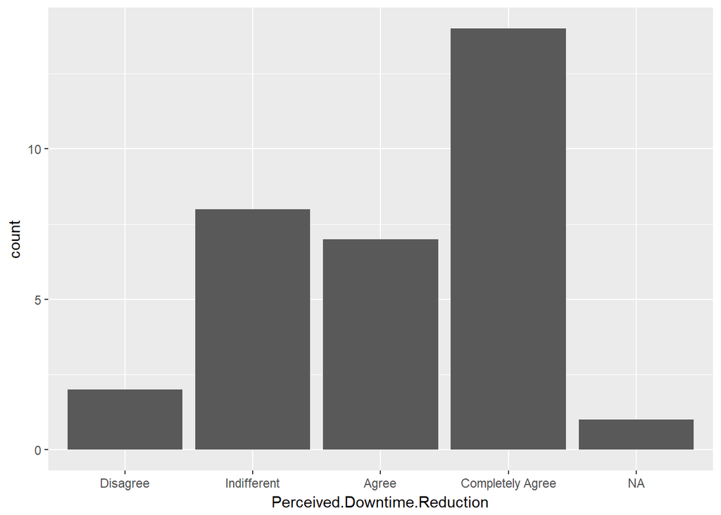

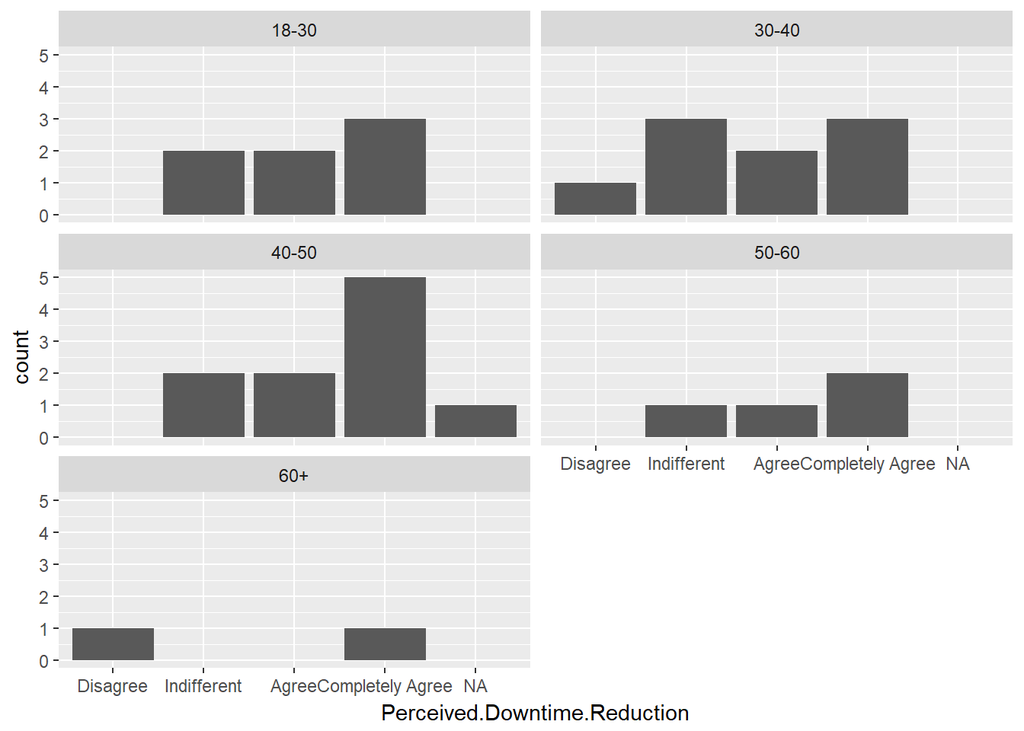

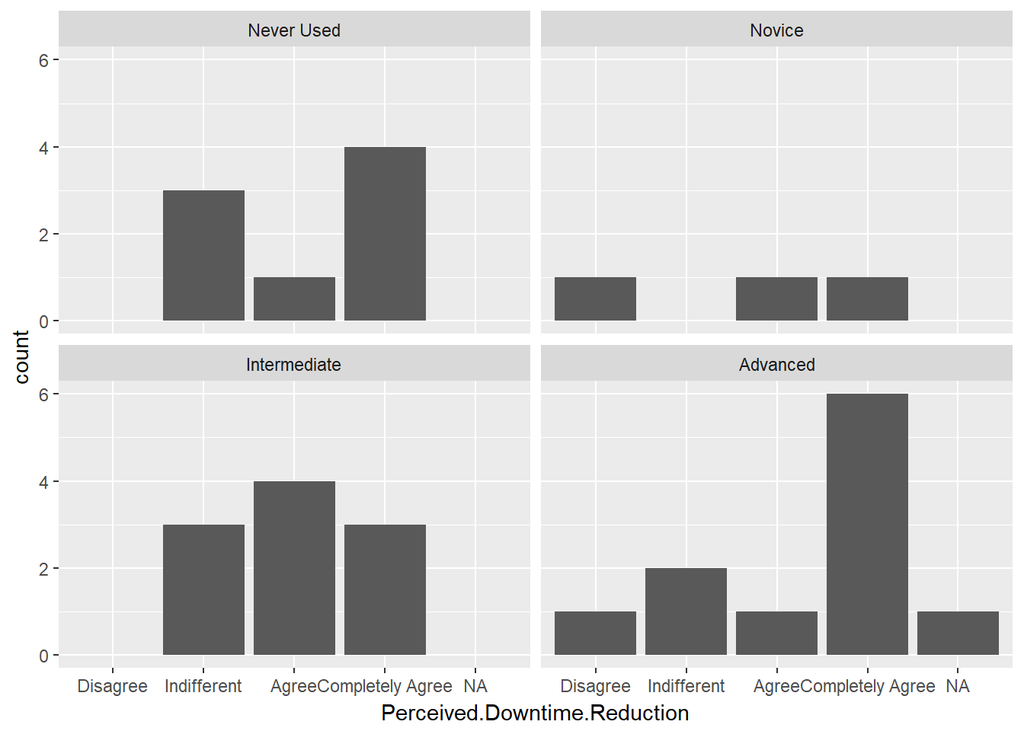

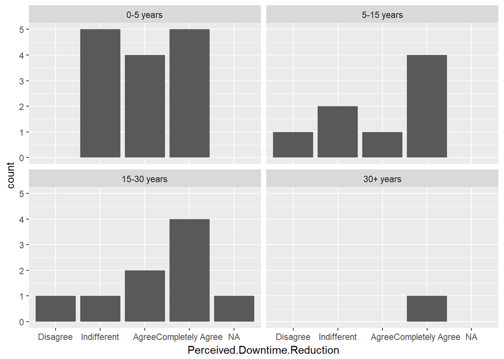

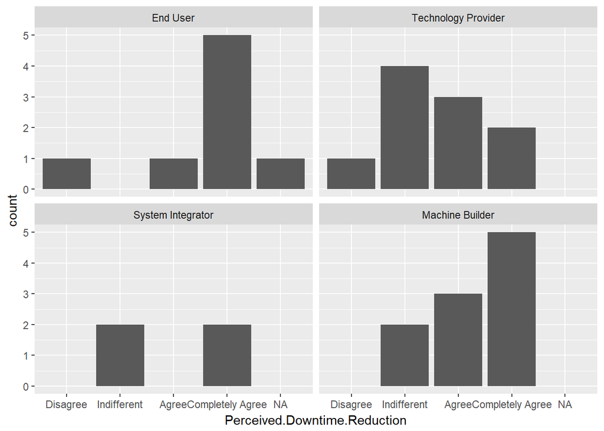

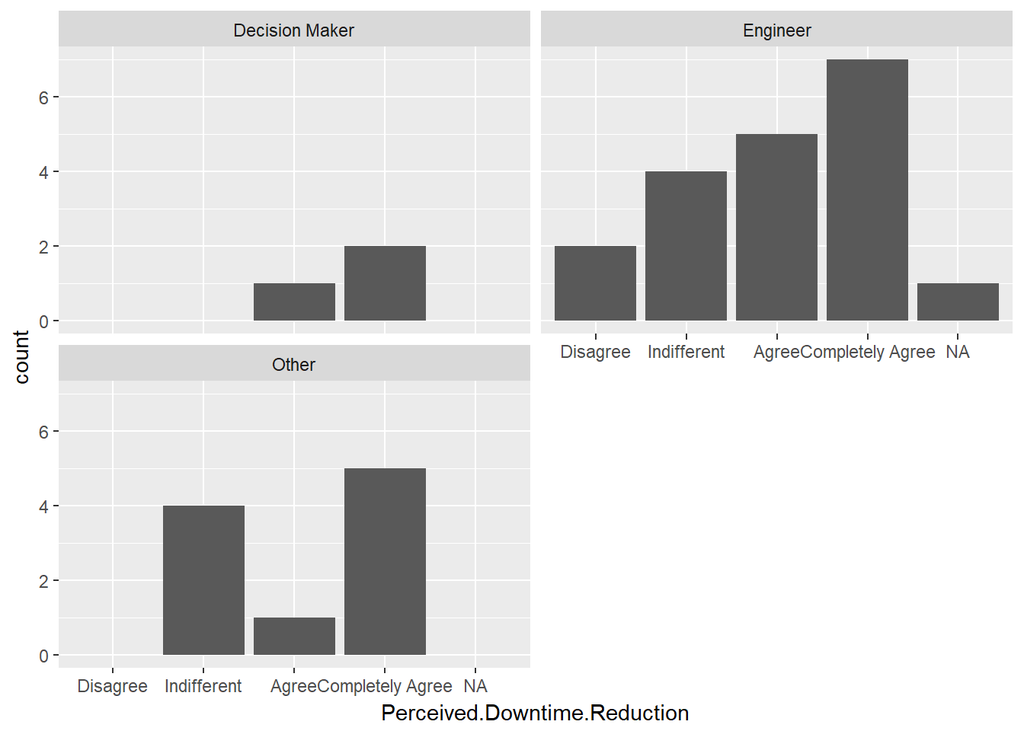

Standardizing on my preferred interface would increase job satisfaction for line operators.

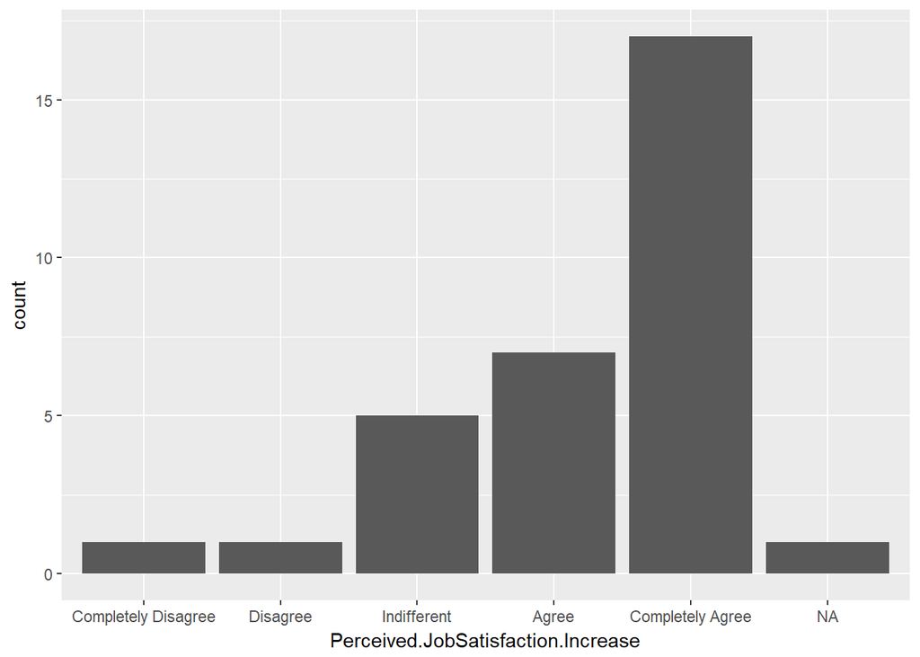

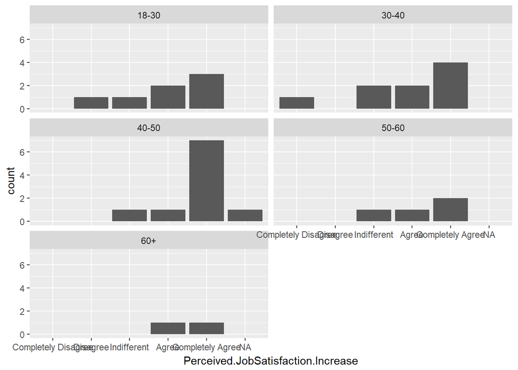

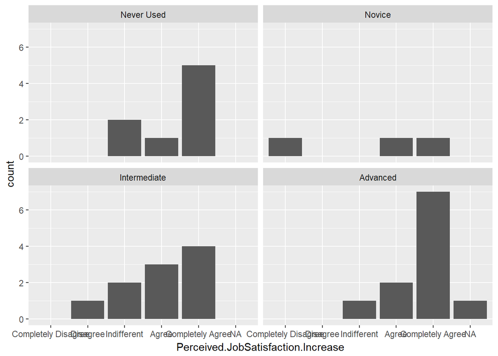

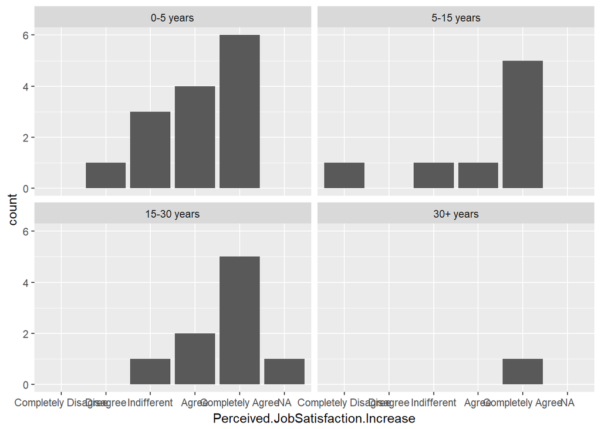

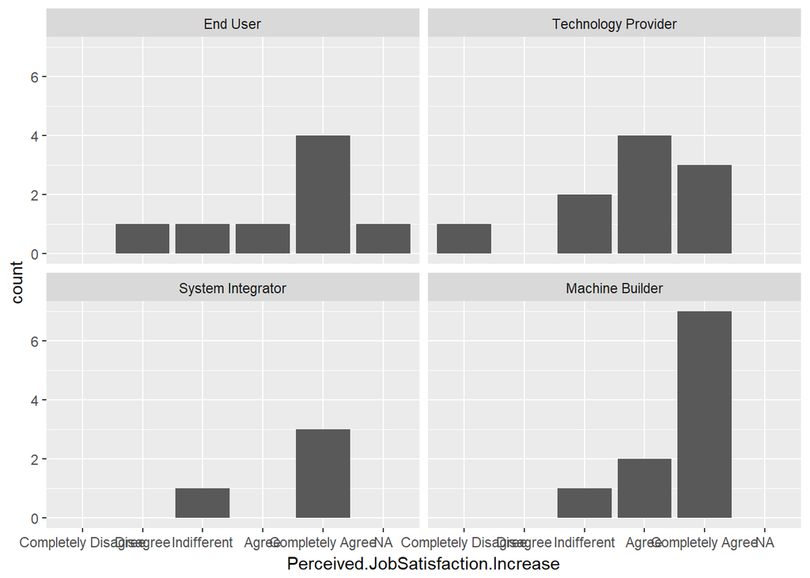

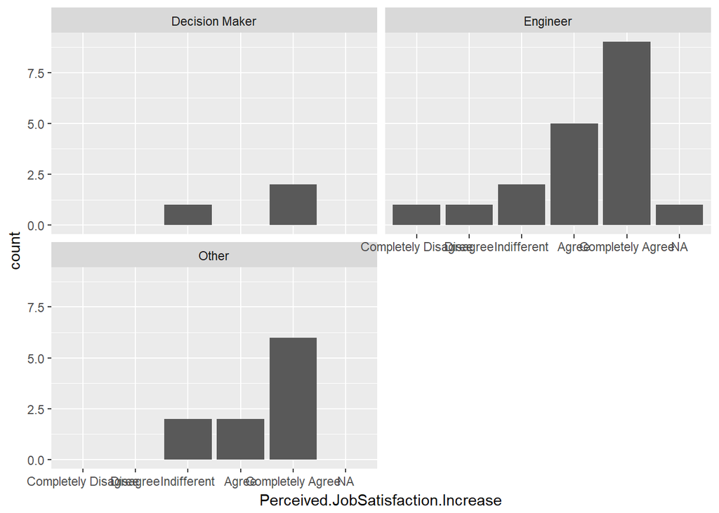

Standardizing on my preferred interface would reduce operator errors caused by poor HMI design.

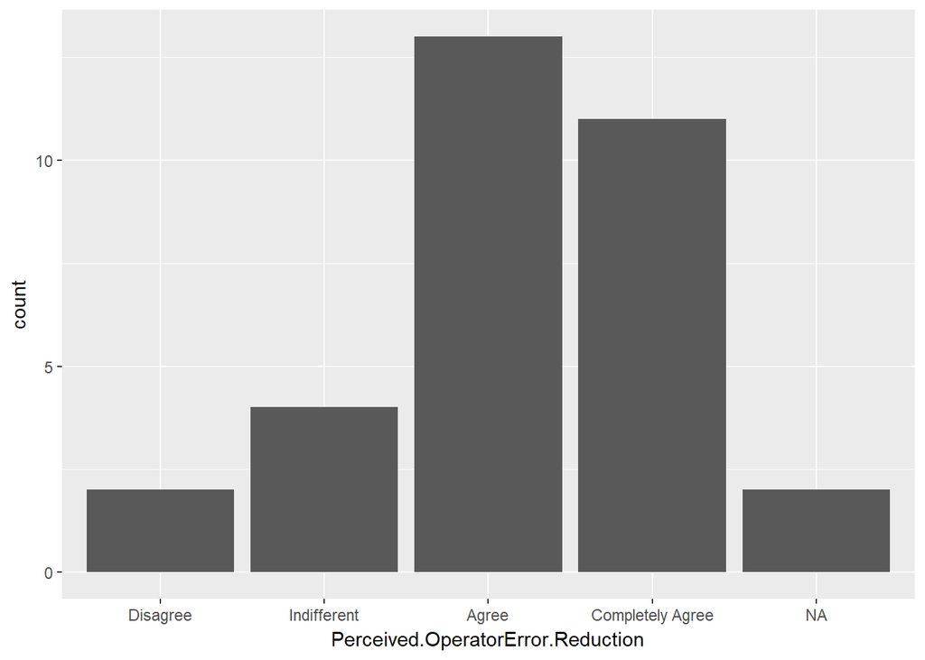

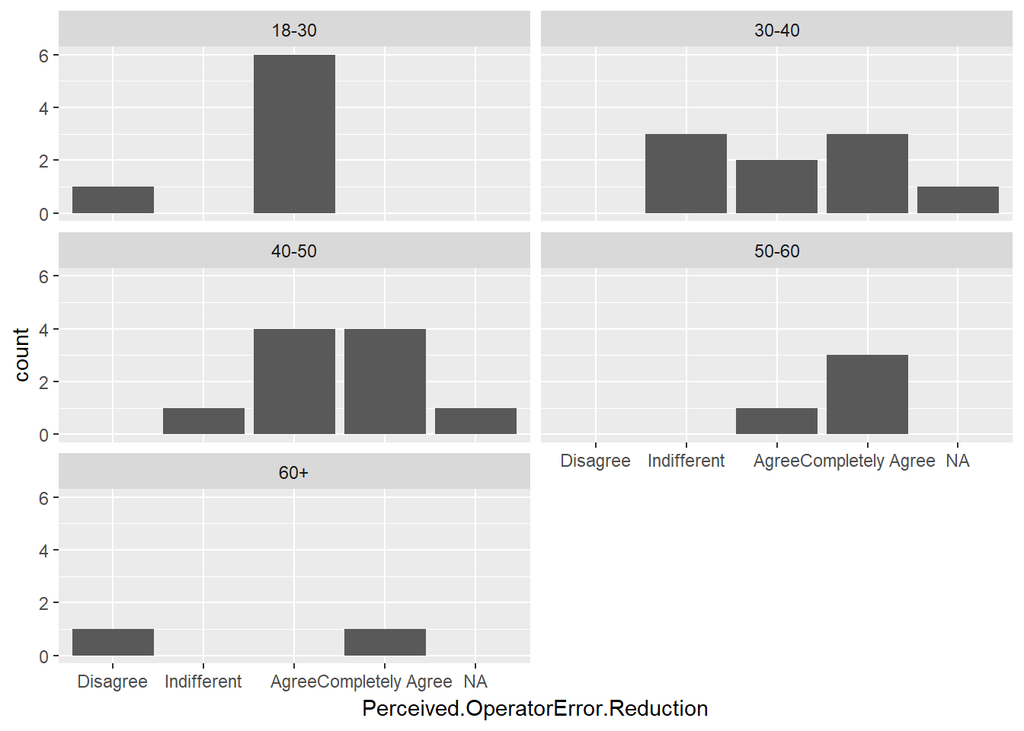

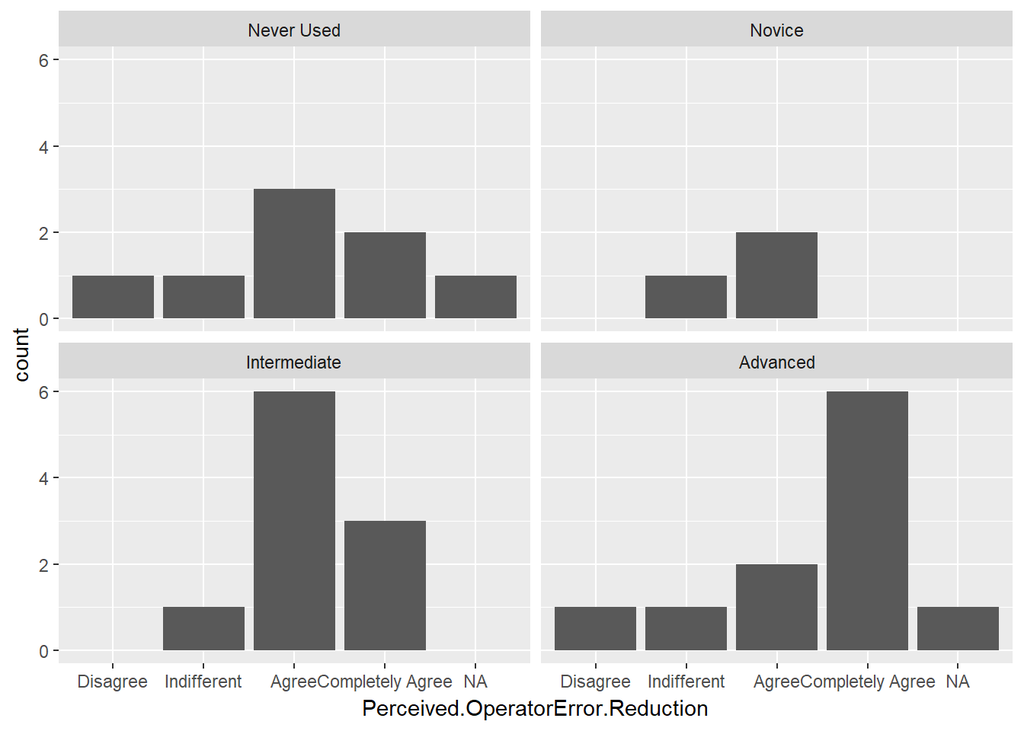

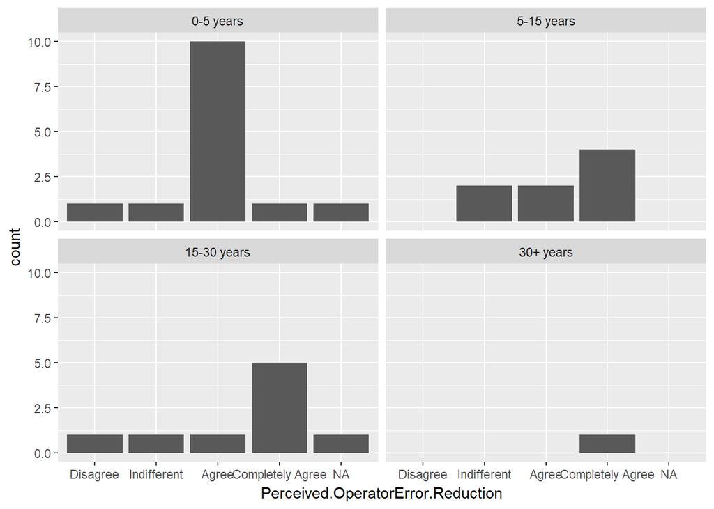

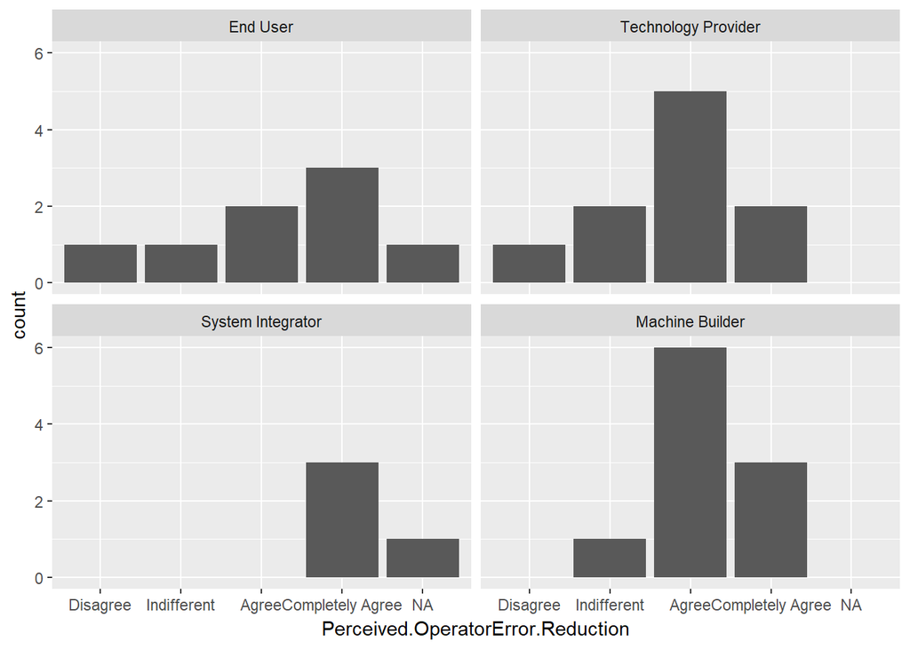

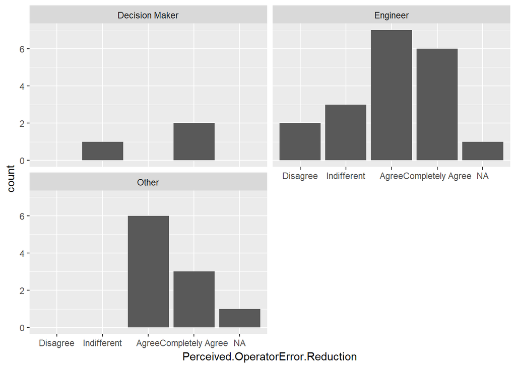

Participating in this evaluation in no way changed my opinion regarding HMI standardization.

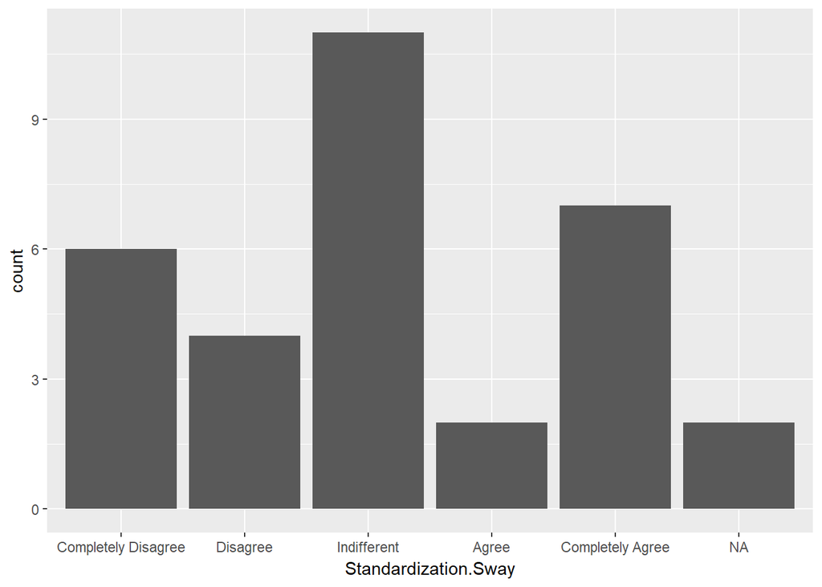

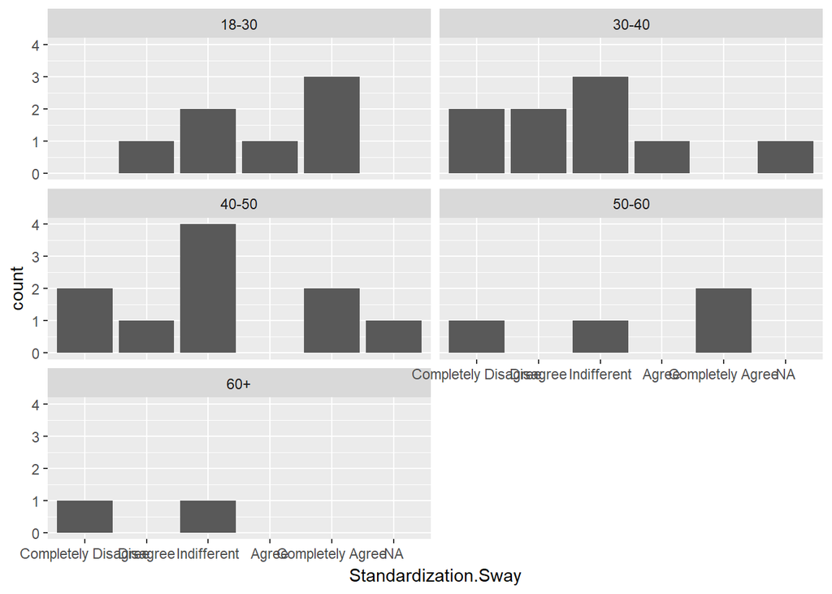

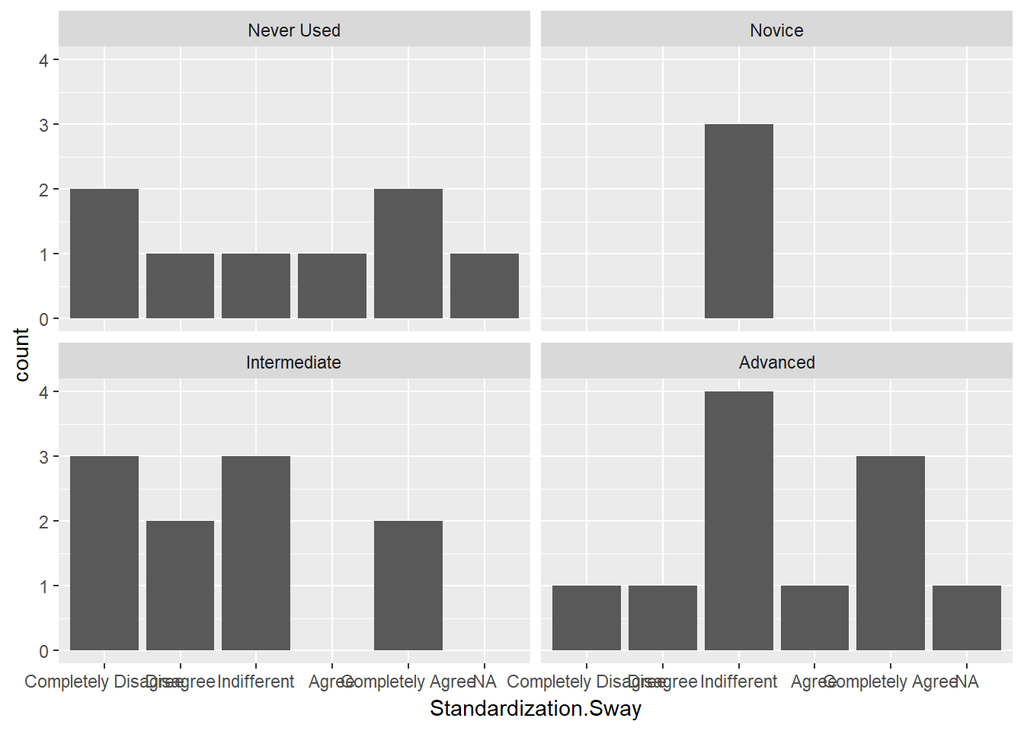

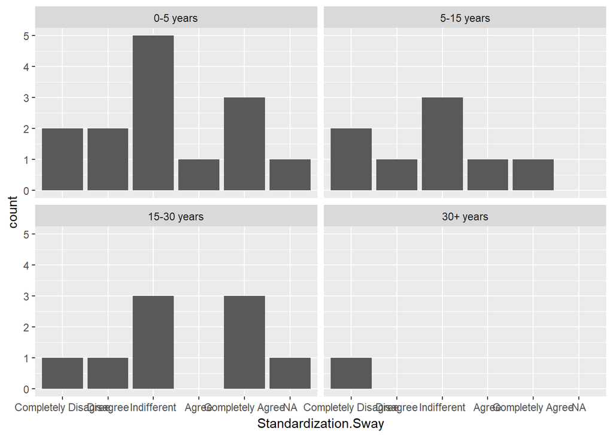

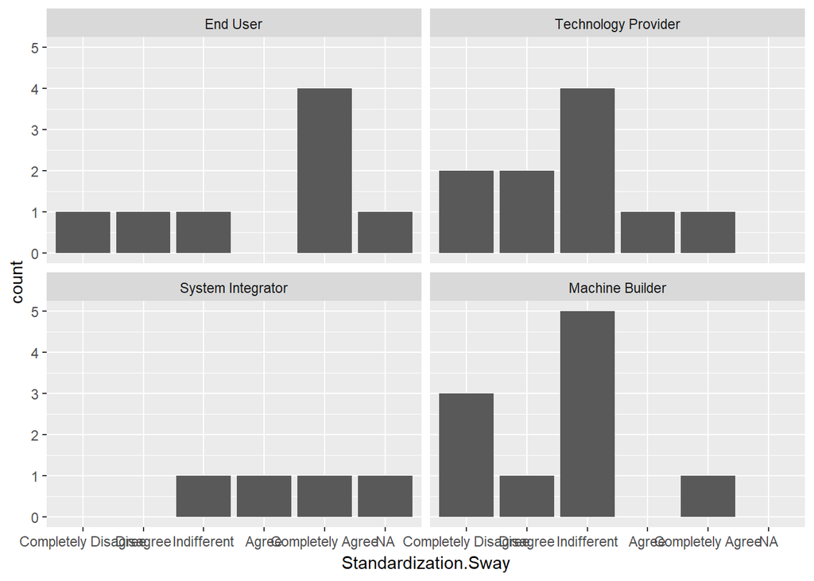

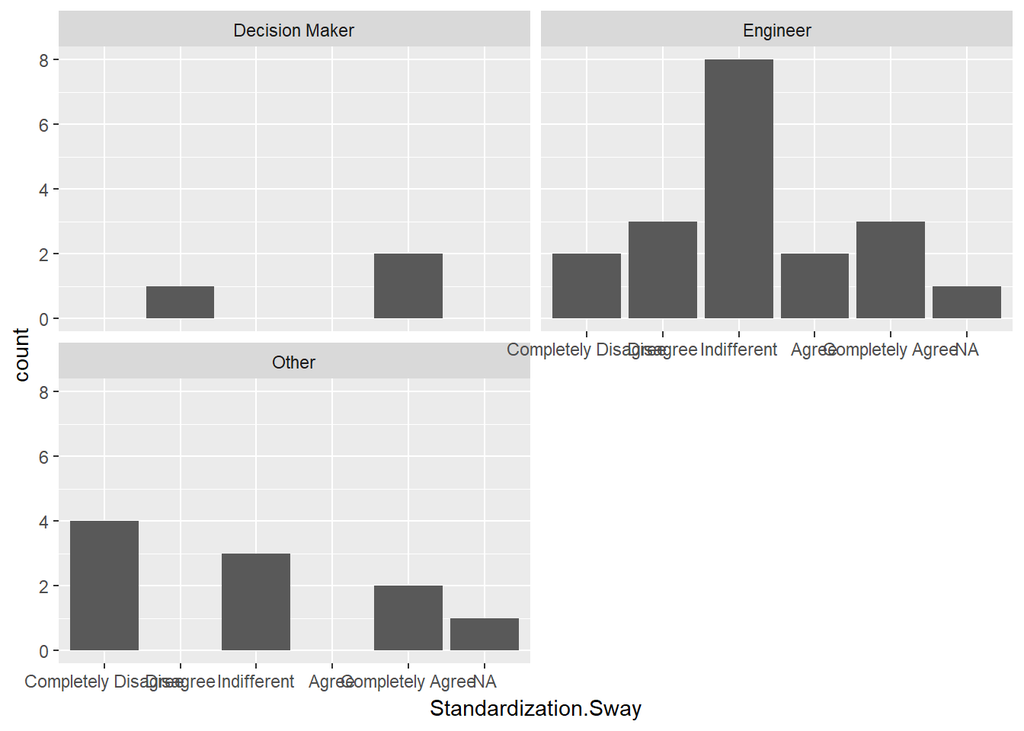